# Lab 9: Spaceborne Lidar

Anthony Stewart

2023-05-21

### Objectives:

- Introduction to full waveform lidar
- Introduction to Global Ecosystem Dynamics Investigation (GEDI) Lidar
  - https://gedi.umd.edu/
  - https://gedi.umd.edu/return-of-the-gedi-space-based-forest-carbon-mapping-laser-array-saved/
- Introduction to The Ice, Cloud and land Elevation Satellite-2, or ICESat-2
  - https://www.nasa.gov/content/goddard/about-icesat-2
- Downloading and using GEDI data
- Characterizing forested landscapes with full waveform lidar

### Data and Software:

- LAB9_GEDI data
- `rGEDI`: An R Package for NASA’s Global Ecosystem Dynamics Investigation (GEDI) Data Visualization and Processing https://cran.r-project.org/web/packages/rGEDI/vignettes/tutorial.html
- ArcGIS Pro

What you will turn in:

Lab 9 Submission Quiz

Welcome to Lab 9 for ESRM433/SEFS533 This lab is all about Spaceborn lidar. We have covered aerial lidar, and terrestrial lidar, now we will talk about spaceborn lidar scanning (SLS). Two prominent spaceborn lidar sensors are ICESat and GEDI.

PART 1a GEDI background

For this lab, we are going to focus on GEDI data. The GEDI sensor was launched to the International Space Station (ISS) in December of 2018 and is slated for a two year mission to scan terrestrial ecosystems. The data collected is limited to the orbit of the ISS so data isn’t available for latitudes greater than 51.6o.

```r
library(devtools)
devtools::install_git("https://github.com/carlos-alberto-silva/rGEDI", dependencies = T)
```

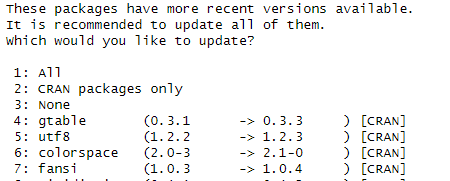

This may take a while to run, especially if you say yes to updating all the packages. I would suggest saying `no` or `3` for now unless you run into a problem related to package versions.

```r
library(rGEDI)
```

For the following questions refer to: - GEDI’s website https://gedi.umd.edu/

GEDI videos - https://www.youtube.com/watch?v=SSdDPFfUVIo - https://www.youtube.com/watch?v=wxgrxvAKpTo - https://www.youtube.com/watch?v=XFlm-TmhvjM

Any other online resources you can find for GEDI and full waveform lidar

The lidar data from GEDI retains it’s full waveform. ALS data is also based on the amount of energy returned from a laser pulse, but the full waveform is discarded and only the peaks in the waveform are preserved. These peaks are what we call returns when using terms like “discreate return lidar” vs “full wavefrom lidar”

The beam divergence of lasers is extremely important to keep in mind when discussion SLS. Beam divergence is in direct relationship to the distance the laser pulse travels. For TLS, objects are much closer to the scanner so beam divergence is likely to be a few mm to a few cm depending on the distance. For ALS, beam divergence can be ~10cm to ~30cm. This divergence is what allows for multiple returns from a single pulse.

**QUESTION 1: Is GEDI data free to the public? Where can you get GEDI data?**

**QUESTION 2: What is the footprint (resolution) of GEDI laser pulses? This is the same as beam divergence.**

**QUESITON 3: How many beams of data is GEDI collecting? What is their spacing?**

**QUESTION 4: Is every square meter of the earths surface getting sampled by GEDI?**

**QUESTION 5: What are the three science questions for GEDI?**

**QUESTION 6: For Data Products, there are multiple Algorithm Theoretical Basis Documents (ATBDs) for GEDI data. We are most interested in L1B, L2A, & L2B. What is the name of the data product for those 3 ATBDs?**

### PART 1b ICESat background

ICESat is like GEDI in many respects. An orbiting lidar sensor in space. A major difference is that GEDI is on the international space station while ICESat has its own dedicated satellite in a polar orbit. Take a moment to review the information here about ICESat: https://www.nasa.gov/content/goddard/about-icesat-2

**QUESTION 7: What are some similarities and some differences between GEDI and ICESat2?**

**QUESITON 8: What wavelength and color is the ICESat2 laser? What wavelength and color is the GEDI laser?**

**QUESTION 9: What is the spacing of the ICESat2 laser pulses?**